# RandomForest

## Random Forest

The main concept behind Random Forests is to generate many decision trees by sampling both, the observations and the variables. Observation are randomized by selecting same number of observations but allowing for observations to be selected again ( with replacement ). Variables are randomized by selecting a small number ( often referred to as m) compared to the total number of observations. Each tree in this forest is grown without any pruning. Pruning is the process of trimming the tree to avoid over-fitting. In this case we donât prune at all.

Now, when an input is provided, all the trees will vote on a given result and the outcome with the most votes will win. One often has to adjust the m to identify the optimal results.

Random Forest is a popular method for predictive analysis because it is fast and less likely to overfit. The observations are randomly selected ( with replacement ) the remaining dataset is referred to as âout of bagâ (OOB) data. This is the same idea as the Leave Out set. Random Forest will try to classify the OOB data and determine accuracy of the model. For this reason one does not have to perform any cross validation, because every time a tree is created, it goes through a round of assesment.

## Variable importance

To calculate whether a variable is imporant you simply perform the following steps:

- Count the number of correct predictions
- For a given variable, simply randomize/shuffle the values and then count the number of correct prediction.
- Repeat this in all tree for that one variable. The average difference of the predictions minus the correct predictions is the importance score of the variable.

Gini impurity is very similar to Entropy ( or the gain of information ) except the calculations are slightly different.

## Dataset

Letâs use our 15K patient data to see how Random Forest performs in our dataset.

We will just use sklearn.ensemble.RandomForestClassifier for the job.

```python
import numpy as np
import pandas as pd
from collections import OrderedDict
from sklearn.ensemble import RandomForestClassifier
from sklearn.tree import export_graphviz
from sklearn import tree
import matplotlib.pyplot as plt
import warnings
import seaborn as sns
```

```python
data = pd.read_csv("all.15k.patients.txt",sep = "\t")
data.head()
```

|  | dateofbirth | maritalstatus | race | ageatdiagnosis | alivestatus | survivaltime | grade | nodesexam | nodespos | extent | nodalstatus | size | pgr | er |
| --- | --- | --- | --- | --- | --- | --- | --- | --- | --- | --- | --- | --- | --- | --- |
| pid00001 | 28/01/1932 | 5 | 2 | 61 | 0 | 110 | 3 | 32 | 3 | 10 | 6 | 60 | 2 | 2 |
| pid00002 | 07/05/1934 | 2 | 3 | 60 | 0 | 100 | 2 | 13 | 1 | 10 | 6 | 15 | 1 | 1 |
| pid00003 | 14/04/1921 | 5 | 3 | 76 | 0 | 70 | 3 | 8 | 0 | 10 | 0 | 8 | 1 | 1 |
| pid00004 | 08/11/1931 | 3 | 3 | 61 | 1 | 31 | 3 | 20 | 0 | 10 | 0 | 10 | 2 | 2 |
| pid00005 | 08/01/1922 | 2 | 3 | 74 | 1 | 47 | 2 | 16 | 8 | 10 | 6 | 15 | 2 | 1 |

Letâs also limit the variables we want to use.

```python
specific_data = data[["alivestatus","grade","nodespos","nodesexam","size","pgr","er"]]

# set alivestatus as categorical
specific_data = specific_data.astype({'alivestatus': 'category'})
```

Writing the randomForest model is the same as writing any other model.

```python
X = np.array(specific_data.iloc[:,1:-1])
y = np.array(specific_data.iloc[:,0])
```

```python
# supress warnings
warnings.simplefilter('ignore')


datarf = RandomForestClassifier(n_estimators=20, oob_score=True)
datarf.fit(X, y)
```

```
RandomForestClassifier(bootstrap=True, class_weight=None, criterion='gini',
                       max_depth=None, max_features='auto', max_leaf_nodes=None,
                       min_impurity_decrease=0.0, min_impurity_split=None,
                       min_samples_leaf=1, min_samples_split=2,
                       min_weight_fraction_leaf=0.0, n_estimators=20,
                       n_jobs=None, oob_score=True, random_state=None,
                       verbose=0, warm_start=False)
```

```python
# calculate the out-of-bag error
print("Out of bag error:" ,1 - datarf.oob_score_)
```

```
Out of bag error: 0.20046666666666668
```

#### Let's see how many trees (estimators) are required for model to have a good performance (visualize oob error vs trees)

```python
# supress warnings
warnings.simplefilter('ignore')

# examine different number of trees from 1 to 100
min_estimators = 5
max_estimators = 50

# results list
n_trees = []
oob_errors = []

# iterate from n_estimators = 5 to n_estimators = 50
for i in range(min_estimators, max_estimators+1):
    clf = RandomForestClassifier(n_estimators=i, oob_score=True, random_state=123)
    clf.fit(X, y)
    n_trees.append(i)
    oob_errors.append(1 - clf.oob_score_)
```

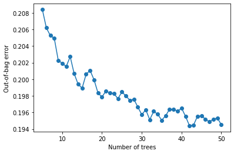

```python
plt.plot(n_trees, oob_errors, '-o')
plt.ylabel('Out-of-bag error')
plt.xlabel('Number of trees')
plt.show()
```

#### Which feature is more important?

```python
# write data into a dataframe for ploting purpose
data = {"importances": datarf.feature_importances_,
        "feature": specific_data.columns[1:-1]}
data4plt = pd.DataFrame(data)
data4plt = data4plt.sort_values(by=['importances'], ascending=False)
data4plt
```

|  | importances | feature |
| --- | --- | --- |
| 2 | 0.337000 | nodesexam |
| 3 | 0.328631 | size |
| 1 | 0.251378 | nodespos |
| 0 | 0.050655 | grade |
| 4 | 0.032337 | pgr |

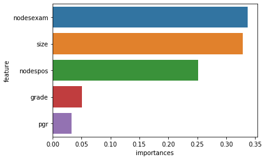

```python
# plot gini importance
sns.barplot(x="importances", y="feature", data=data4plt)
```

## Exercise

Try use the value *m* using the **max_features** option in **RandomForestClassifier**. Do the results get better or worse?

## Drawing a tree

The following code was obtained from [stack overflow](https://stackoverflow.com/a/61037626/11948997).

```python
fn=list(specific_data.columns[1:-1])
cn=specific_data.columns[0]
fig, axes = plt.subplots(nrows = 4,ncols = 5,figsize = (10,7), dpi=900)
for index in range(0, len(datarf.estimators_)):
    tree.plot_tree(datarf.estimators_[index],
                   feature_names = fn,
                   max_depth = 2,
                   class_names=cn,
                   filled = True,
                   ax = axes[int(index / 5), index %5]);

    axes[int(index / 5), index %5].set_title('Estimator: ' + str(index), fontsize = 11)
```

[figure not shown]